# Instrumental Variable Test

Bas Machielsen

11/15/2020

## Introductie

Een korte test van IV-estimation voor Paper 2: Wealth on Voting Behavior. Ik neem alle resultaten van **fiscale wetgeving**: daar zijn de resultaten het meest significant.

## Resultaten zonder IV

Recap van de resultaten zonder IV:

We zien dat:

```r
stargazer(all1, all11, all2, all6, all7,
          font.size = "scriptsize",
          column.sep.width = "0pt",
          dep.var.labels.include = F, type = "html")
```

|  | *Dependent variable:* |  |  |  |  |
| --- | --- | --- | --- | --- | --- |
|  | (1) | (2) | (3) | (4) | (5) |
| log(1 + wealth_timevote) | -0.143* | -0.249** |  |  |  |
|  | (0.083) | (0.103) |  |  |  |
| services_share |  | 0.400 |  |  | 1.551 |
|  |  | (0.840) |  |  | (1.109) |
| nearestcompetitormargin |  | 0.007 |  |  | 0.002 |
|  |  | (0.009) |  |  | (0.012) |
| amount_strikes |  | -0.051 |  | 0.021 | 0.071 |
|  |  | (0.065) |  | (0.103) | (0.117) |
| Percentage |  | -0.001 |  | 0.005 | 0.009 |
|  |  | (0.013) |  | (0.010) | (0.016) |
| Turnout |  | -0.737 |  | 1.006 | 0.896 |
|  |  | (1.077) |  | (1.374) | (1.464) |
| days_to_next_el |  | 0.0001 |  | -0.002 | -0.002 |
|  |  | (0.001) |  | (0.002) | (0.002) |
| age_of_vote |  | -0.0001 |  | -0.00004 | -0.0001 |
|  |  | (0.00005) |  | (0.0001) | (0.0001) |
| RK_pct |  | -0.023*** |  | -0.021** | -0.026*** |
|  |  | (0.008) |  | (0.009) | (0.010) |
| polpartyliberal | 2.354*** | 2.174*** | 4.125*** | 3.611*** | 3.298*** |
|  | (0.305) | (0.443) | (0.539) | (0.634) | (0.639) |
| polpartysocialist | 3.195*** | 2.620*** | 7.007*** | 5.351*** | 5.179*** |
|  | (0.756) | (0.890) | (1.252) | (1.409) | (1.504) |
| log(1 + wealth_timevote):lawInkomstenbelasting 1893 |  |  | -0.225** | -0.408*** | -0.422*** |
|  |  |  | (0.110) | (0.141) | (0.148) |
| log(1 + wealth_timevote):lawInkomstenbelasting 1914 |  |  | -0.058 | -0.073 | -0.024 |
|  |  |  | (0.110) | (0.146) | (0.159) |
| log(1 + wealth_timevote):lawStaatsschuldwet 1914 |  |  | -0.646*** | -0.707*** | -0.745*** |
|  |  |  | (0.136) | (0.164) | (0.174) |
| log(1 + wealth_timevote):lawSuccessiewet 1911 |  |  | -0.003 | -0.167 | -0.221 |
|  |  |  | (0.108) | (0.135) | (0.146) |
| log(1 + wealth_timevote):lawSuccessiewet 1916 |  |  | -0.235** | -0.440*** | -0.442*** |
|  |  |  | (0.114) | (0.153) | (0.163) |
| log(1 + wealth_timevote):lawSuccessiewet1878 |  |  | -0.186* | -0.334** | -0.354** |
|  |  |  | (0.107) | (0.137) | (0.144) |
| Constant | 0.951 | 4.365** | 1.066 | 4.502* | 4.214 |
|  | (0.901) | (1.838) | (1.122) | (2.443) | (2.711) |
| Observations | 301 | 237 | 301 | 247 | 237 |
| Log Likelihood | -153.342 | -112.646 | -97.828 | -82.173 | -75.790 |
| Akaike Inf. Crit. | 314.684 | 249.293 | 213.656 | 194.346 | 185.580 |
| *Note:* | p<0.1; p<0.05; p<0.01 |  |  |  |  |

## Merge data met Parental Wealth

```r
parwealth <- read_xlsx("../../Data/instrumental_variable_est.xlsx") %>%
  mutate(across(c(wealth_father, wealth_mother, wealth_misc), ~ as.numeric(.x)))
```

De data eerst deflaten:

```r
inflation <- read_xlsx("../../Data/AnalysisFile.xlsx", sheet = "InflationGDP")
```

Nu merge met fiscal en clean:

```r
fiscal2 <- left_join(fiscal, parwealth, by = c("polid" = "polid")) %>%
  rowwise() %>%
  mutate(date = ymd(date),
        max = pmax(wealth_father, wealth_mother, wealth_misc, na.rm = TRUE)
        ) %>%
  mutate(harnas = dateofdeath.x - date < 1800) %>%
  mutate(max_alt = if_else(isTRUE(harnas) & is.na(max), as.numeric(wealth_timevote), max))
```

## Voorlopige resultaten met IV

Resultaat 1: Het is een goed instrument

Redelijk sterk verband tussen log(max) (hoogste van father, mother, misc indien aanwezig)

```r
test <- lm(log(1+wealth_timevote) ~ log(max), data = fiscal2)

summary(test)
```

```
##
## Call:
## lm(formula = log(1 + wealth_timevote) ~ log(max), data = fiscal2)
##
## Residuals:
##    Min     1Q Median     3Q    Max
## -4.466 -0.892 -0.128  1.000  2.968
##
## Coefficients:
##             Estimate Std. Error t value Pr(>|t|)
## (Intercept)  7.80261    0.83082   9.391 1.97e-15 ***
## log(max)     0.32216    0.07242   4.449 2.23e-05 ***
## ---
## Signif. codes:  0 '***' 0.001 '**' 0.01 '*' 0.05 '.' 0.1 ' ' 1
##
## Residual standard error: 1.438 on 101 degrees of freedom
##   (435 observations deleted due to missingness)
## Multiple R-squared:  0.1638, Adjusted R-squared:  0.1556
## F-statistic: 19.79 on 1 and 101 DF,  p-value: 2.226e-05
```

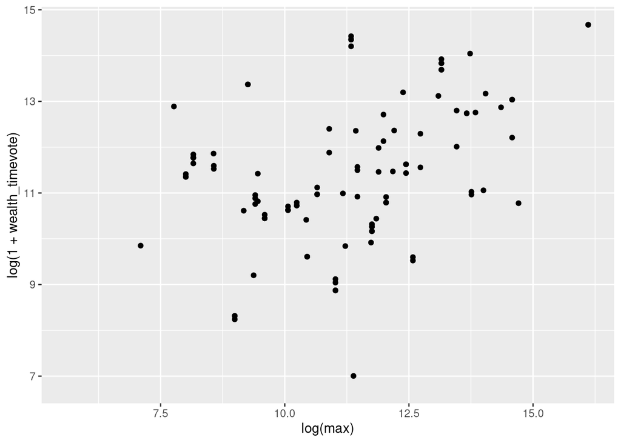

```r
ggplot(data = fiscal2, aes(x = log(max), y = log(1+wealth_timevote))) + geom_point()
```

```r
test2 <- lm(as.numeric(vote) ~ log(1+wealth_timevote) + polparty, data = fiscal2)
summary(test2)
```

```
##
## Call:
## lm(formula = as.numeric(vote) ~ log(1 + wealth_timevote) + polparty,
##     data = fiscal2)
##
## Residuals:
##     Min      1Q  Median      3Q     Max
## -0.9159 -0.3413  0.1140  0.1778  0.7227
##
## Coefficients:
##                          Estimate Std. Error t value Pr(>|t|)
## (Intercept)               0.61770    0.15153   4.077 5.86e-05 ***
## log(1 + wealth_timevote) -0.02402    0.01362  -1.764   0.0787 .
## polpartyliberal           0.49753    0.05008   9.935  < 2e-16 ***
## polpartysocialist         0.56158    0.08328   6.743 8.01e-11 ***
## ---
## Signif. codes:  0 '***' 0.001 '**' 0.01 '*' 0.05 '.' 0.1 ' ' 1
##
## Residual standard error: 0.4113 on 299 degrees of freedom
##   (235 observations deleted due to missingness)
## Multiple R-squared:  0.281,  Adjusted R-squared:  0.2738
## F-statistic: 38.95 on 3 and 299 DF,  p-value: < 2.2e-16
```

Univariaat nog geen sterk verband (Dit is goed, want het instrument en de dep var moeten ongecorreleerd zijn):

```r
test3 <- lm(as.numeric(vote) ~ log(1+max) + polparty, data = fiscal2)
summary(test3)
```

```
##
## Call:
## lm(formula = as.numeric(vote) ~ log(1 + max) + polparty, data = fiscal2)
##
## Residuals:
##     Min      1Q  Median      3Q     Max
## -0.8874 -0.3789  0.2236  0.2331  0.6303
##
## Coefficients:
##                   Estimate Std. Error t value Pr(>|t|)
## (Intercept)       0.352010   0.175370   2.007  0.04718 *
## log(1 + max)      0.002279   0.014741   0.155  0.87742
## polpartyliberal   0.392984   0.088702   4.430 2.23e-05 ***
## polpartysocialist 0.514345   0.164311   3.130  0.00224 **
## ---
## Signif. codes:  0 '***' 0.001 '**' 0.01 '*' 0.05 '.' 0.1 ' ' 1
##
## Residual standard error: 0.4529 on 110 degrees of freedom
##   (424 observations deleted due to missingness)
## Multiple R-squared:  0.1775, Adjusted R-squared:  0.1551
## F-statistic: 7.914 on 3 and 110 DF,  p-value: 7.924e-05
```

Dit zijn een paar simpele IV-regressies. Ik gebruik twee variaties:

- max: $ (WoD_{father}, WoD_{mother}, WoD_{misc}) $
- max_alt: max if available, wealth_timevote if (not available & harnas), na otherwise

```r
test2 <- ivreg(as.numeric(vote) ~ log(1+wealth_timevote) + polparty | polparty + log(1+max), data = fiscal2)

summary(test2)
```

```
##
## Call:
## ivreg(formula = as.numeric(vote) ~ log(1 + wealth_timevote) +
##     polparty | polparty + log(1 + max), data = fiscal2)
##
## Residuals:
##     Min      1Q  Median      3Q     Max
## -0.8503 -0.3856  0.2138  0.2339  0.6393
##
## Coefficients:
##                          Estimate Std. Error t value Pr(>|t|)
## (Intercept)               0.48592    0.88197   0.551   0.5829
## log(1 + wealth_timevote) -0.00905    0.07732  -0.117   0.9071
## polpartyliberal           0.39225    0.09287   4.224 5.35e-05 ***
## polpartysocialist         0.48542    0.20780   2.336   0.0215 *
## ---
## Signif. codes:  0 '***' 0.001 '**' 0.01 '*' 0.05 '.' 0.1 ' ' 1
##
## Residual standard error: 0.4547 on 99 degrees of freedom
## Multiple R-Squared: 0.1706,  Adjusted R-squared: 0.1454
## Wald test: 6.752 on 3 and 99 DF,  p-value: 0.0003435
```

```r
test3 <- ivreg(as.numeric(vote) ~ log(1+wealth_timevote) +
        polparty | log(max) +
        polparty, data = fiscal2)

summary(test3)
```

```
##
## Call:
## ivreg(formula = as.numeric(vote) ~ log(1 + wealth_timevote) +
##     polparty | log(max) + polparty, data = fiscal2)
##
## Residuals:
##     Min      1Q  Median      3Q     Max
## -0.8503 -0.3856  0.2138  0.2339  0.6393
##
## Coefficients:
##                           Estimate Std. Error t value Pr(>|t|)
## (Intercept)               0.485907   0.881994   0.551   0.5829
## log(1 + wealth_timevote) -0.009049   0.077319  -0.117   0.9071
## polpartyliberal           0.392249   0.092871   4.224 5.35e-05 ***
## polpartysocialist         0.485416   0.207801   2.336   0.0215 *
## ---
## Signif. codes:  0 '***' 0.001 '**' 0.01 '*' 0.05 '.' 0.1 ' ' 1
##
## Residual standard error: 0.4547 on 99 degrees of freedom
## Multiple R-Squared: 0.1706,  Adjusted R-squared: 0.1454
## Wald test: 6.752 on 3 and 99 DF,  p-value: 0.0003435
```

```r
## Meer controlevariabelen:
test4 <- ivreg(as.numeric(vote) ~ log(1+wealth_timevote) +
           nearestcompetitormargin +
        age_of_vote +
        RK_pct +
        polparty | log(max) +
           nearestcompetitormargin +
        age_of_vote +
        RK_pct +
        polparty, data = fiscal2)

summary(test4)
```

```
##
## Call:
## ivreg(formula = as.numeric(vote) ~ log(1 + wealth_timevote) +
##     nearestcompetitormargin + age_of_vote + RK_pct + polparty |
##     log(max) + nearestcompetitormargin + age_of_vote + RK_pct +
##         polparty, data = fiscal2)
##
## Residuals:
##      Min       1Q   Median       3Q      Max
## -0.86366 -0.37547  0.08188  0.31494  0.89194
##
## Coefficients:
##                            Estimate Std. Error t value Pr(>|t|)
## (Intercept)               1.695e+00  9.452e-01   1.794   0.0773 .
## log(1 + wealth_timevote) -6.284e-02  7.921e-02  -0.793   0.4303
## nearestcompetitormargin  -7.677e-04  1.953e-03  -0.393   0.6955
## age_of_vote              -2.500e-05  1.416e-05  -1.765   0.0820 .
## RK_pct                   -2.301e-03  2.394e-03  -0.961   0.3400
## polpartyliberal           3.387e-01  1.299e-01   2.606   0.0112 *
## polpartysocialist         4.814e-01  3.430e-01   1.404   0.1650
## ---
## Signif. codes:  0 '***' 0.001 '**' 0.01 '*' 0.05 '.' 0.1 ' ' 1
##
## Residual standard error: 0.4639 on 68 degrees of freedom
## Multiple R-Squared: 0.2128,  Adjusted R-squared: 0.1434
## Wald test:  3.43 on 6 and 68 DF,  p-value: 0.005112
```

```r
test5 <- ivreg(as.numeric(vote) ~ log(1+wealth_timevote) +
        polparty | log(max_alt) +
        polparty, data = fiscal2)

summary(test5)
```

```
##
## Call:
## ivreg(formula = as.numeric(vote) ~ log(1 + wealth_timevote) +
##     polparty | log(max_alt) + polparty, data = fiscal2)
##
## Residuals:
##     Min      1Q  Median      3Q     Max
## -0.8956 -0.3273  0.1602  0.2077  0.7164
##
## Coefficients:
##                          Estimate Std. Error t value Pr(>|t|)
## (Intercept)               0.49232    0.34206   1.439    0.152
## log(1 + wealth_timevote) -0.01473    0.03031  -0.486    0.628
## polpartyliberal           0.47999    0.07205   6.662 4.82e-10 ***
## polpartysocialist         0.60017    0.12958   4.632 7.81e-06 ***
## ---
## Signif. codes:  0 '***' 0.001 '**' 0.01 '*' 0.05 '.' 0.1 ' ' 1
##
## Residual standard error: 0.4245 on 150 degrees of freedom
## Multiple R-Squared: 0.2574,  Adjusted R-squared: 0.2426
## Wald test: 17.26 on 3 and 150 DF,  p-value: 1.114e-09
```

```r
test6 <- ivreg(as.numeric(vote) ~ log(1+wealth_timevote) +
           nearestcompetitormargin +
        age_of_vote +
        RK_pct +
        polparty | log(max_alt) +
           nearestcompetitormargin +
        age_of_vote +
        RK_pct +
        polparty, data = fiscal2)

summary(test6)
```

```
##
## Call:
## ivreg(formula = as.numeric(vote) ~ log(1 + wealth_timevote) +
##     nearestcompetitormargin + age_of_vote + RK_pct + polparty |
##     log(max_alt) + nearestcompetitormargin + age_of_vote + RK_pct +
##         polparty, data = fiscal2)
##
## Residuals:
##      Min       1Q   Median       3Q      Max
## -0.89964 -0.28775  0.04499  0.24856  0.94791
##
## Coefficients:
##                            Estimate Std. Error t value Pr(>|t|)
## (Intercept)               1.356e+00  4.034e-01   3.361  0.00106 **
## log(1 + wealth_timevote) -3.738e-02  3.195e-02  -1.170  0.24443
## nearestcompetitormargin  -1.026e-03  1.570e-03  -0.654  0.51476
## age_of_vote              -2.201e-05  1.038e-05  -2.120  0.03620 *
## RK_pct                   -3.244e-03  1.842e-03  -1.762  0.08091 .
## polpartyliberal           4.279e-01  9.930e-02   4.309 3.56e-05 ***
## polpartysocialist         4.749e-01  1.916e-01   2.479  0.01469 *
## ---
## Signif. codes:  0 '***' 0.001 '**' 0.01 '*' 0.05 '.' 0.1 ' ' 1
##
## Residual standard error: 0.4187 on 111 degrees of freedom
## Multiple R-Squared: 0.3208,  Adjusted R-squared: 0.2841
## Wald test: 8.992 on 6 and 111 DF,  p-value: 5.297e-08
```

```r
test7 <- ivreg(as.numeric(vote) ~ log(1+wealth_timevote) +
             services_share +
           nearestcompetitormargin +
        amount_strikes +
        Percentage +
        Turnout +
        days_to_next_el +
        age_of_vote +
        RK_pct +
        polparty | log(max_alt) +
             services_share +
           nearestcompetitormargin +
        amount_strikes +
        Percentage +
        Turnout +
        days_to_next_el +
        age_of_vote +
        RK_pct +
        polparty, data = fiscal2)

summary(test7)
```

```
##
## Call:
## ivreg(formula = as.numeric(vote) ~ log(1 + wealth_timevote) +
##     services_share + nearestcompetitormargin + amount_strikes +
##     Percentage + Turnout + days_to_next_el + age_of_vote + RK_pct +
##     polparty | log(max_alt) + services_share + nearestcompetitormargin +
##     amount_strikes + Percentage + Turnout + days_to_next_el +
##     age_of_vote + RK_pct + polparty, data = fiscal2)
##
## Residuals:
##       Min        1Q    Median        3Q       Max
## -0.862056 -0.240640  0.002636  0.264457  0.940920
##
## Coefficients:
##                            Estimate Std. Error t value Pr(>|t|)
## (Intercept)               1.306e+00  5.536e-01   2.360 0.020147 *
## log(1 + wealth_timevote) -4.023e-02  3.513e-02  -1.145 0.254759
## services_share           -9.674e-02  2.260e-01  -0.428 0.669440
## nearestcompetitormargin  -4.525e-03  2.600e-03  -1.740 0.084740 .
## amount_strikes            7.099e-03  1.377e-02   0.516 0.607139
## Percentage                6.512e-03  3.424e-03   1.902 0.059902 .
## Turnout                  -1.642e-01  2.971e-01  -0.553 0.581670
## days_to_next_el          -9.404e-06  1.468e-04  -0.064 0.949043
## age_of_vote              -2.239e-05  1.088e-05  -2.058 0.042111 *
## RK_pct                   -3.667e-03  1.904e-03  -1.926 0.056758 .
## polpartyliberal           3.876e-01  1.090e-01   3.557 0.000563 ***
## polpartysocialist         4.269e-01  2.210e-01   1.932 0.056069 .
## ---
## Signif. codes:  0 '***' 0.001 '**' 0.01 '*' 0.05 '.' 0.1 ' ' 1
##
## Residual standard error: 0.4204 on 105 degrees of freedom
## Multiple R-Squared: 0.3484,  Adjusted R-squared: 0.2802
## Wald test: 5.175 on 11 and 105 DF,  p-value: 1.871e-06
```

## Resultaat 2

Het instrument lijkt stabiele point estimates te geven in de juiste richting, maar nog te kleine sample om significantieniveaus te halen..